# Neural Network

==> Neural networks are parallel computing devices, which is basically an attempt to make a computer model of the brain.

==> The main objective is to develop a system to perform various computational tasks faster than the traditional systems.

==> These tasks include pattern recognition and classification, approximation, optimization, and data clustering.

**Working of a Biological Neuron**

==> **Dendrites** − They are tree-like branches, responsible for receiving the information from other neurons it is connected to. In other sense, we can say that they are like the ears of neuron.

==> **Soma** − It is the cell body of the neuron and is responsible for processing of information, they have received from dendrites.

==> **Axon** − It is just like a cable through which neurons send the information.

==> **Synapses** − It is the connection between the axon and other neuron dendrites.

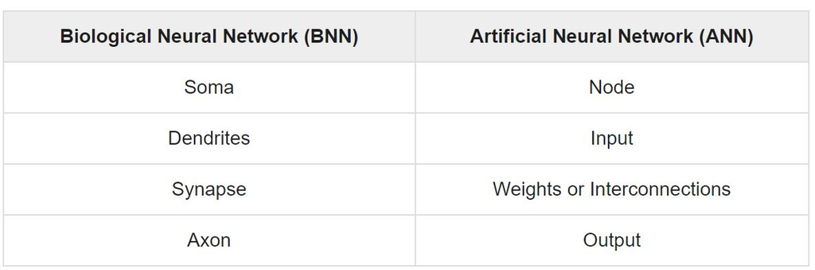

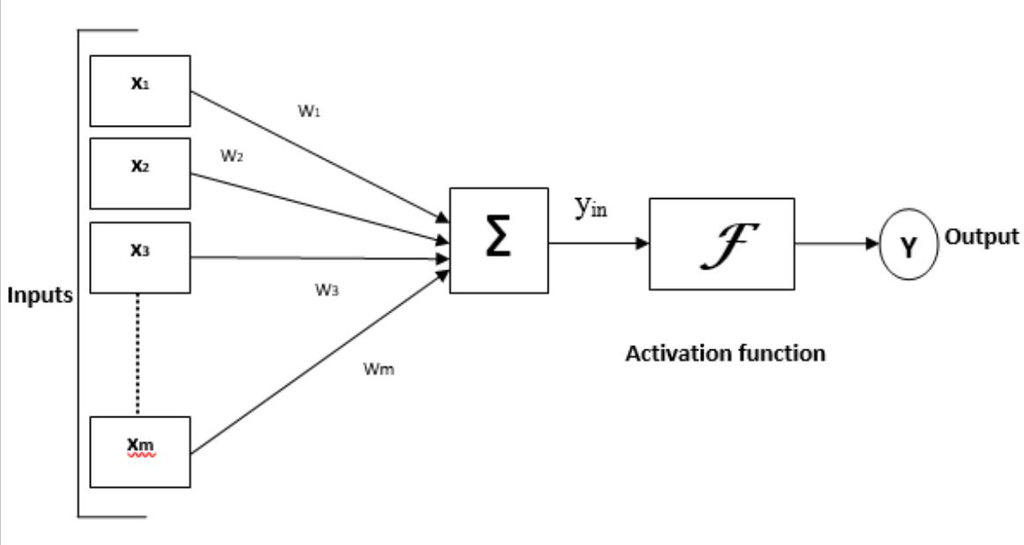

### Example of Neural Network

### Speech Recognition

==> Speech occupies a prominent role in human-human interaction. Therefore, it is natural for people to expect speech interfaces with computers. In the present era, for communication with machines, humans still need sophisticated languages which are difficult to learn and use. To ease this communication barrier, a simple solution could be, communication in a spoken language that is possible for the machine to understand.

==> Great progress has been made in this field, however, still such kinds of systems are facing the problem of limited vocabulary or grammar along with the issue of retraining of the system for different speakers in different conditions. ANN is playing a major role in this area. Following ANNs have been used for speech recognition −

```
==> Multilayer networks

==> Multilayer networks with recurrent connections

==> self-organizing feature map
```

### Character Recognition

==> It is an interesting problem which falls under the general area of Pattern Recognition. Many neural networks have been developed for automatic recognition of handwritten characters, either letters or digits. Following are some ANNs which have been used for character recognition −

```
==> Multilayer neural networks such as Backpropagation neural networks.
==> Neocognitron
```

==> Though back-propagation neural networks have several hidden layers, the pattern of connection from one layer to the next is localized. Similarly, neocognitron also has several hidden layers and its training is done layer by layer for such kind of applications.

### Signature Verification Application

==> Signatures are one of the most useful ways to authorize and authenticate a person in legal transactions. Signature verification technique is a non-vision based technique.

==> For this application, the first approach is to extract the feature or rather the geometrical feature set representing the signature. With these feature sets, we have to train the neural networks using an efficient neural network algorithm. This trained neural network will classify the signature as being genuine or forged under the verification stage.

### Human Face Recognition

==> It is one of the biometric methods to identify the given face. It is a typical task because of the characterization of “non-face” images. However, if a neural network is well trained, then it can be divided into two classes namely images having faces and images that do not have faces.

==> First, all the input images must be preprocessed. Then, the dimensionality of that image must be reduced. And, at last it must be classified using neural network training algorithm. Following neural networks are used for training purposes with preprocessed image −

```
==> Fully-connected multilayer feed-forward neural network trained with the help of back-propagation algorithm.

==> For dimensionality reduction, Principal Component Analysis (PCA) is used.
```